# Returning to this project after a little bit.

Instead of picking up right back where I left off, I'm going to quickly re-do some of the results along the way

```python
import matplotlib as mpl
import matplotlib.pyplot as plt
%matplotlib inline
from IPython.core.pylabtools import figsize

import seaborn as sns
import plotly.express as px

import numpy as np
import pandas as pd

import statsmodels.formula.api as smf

import torch
```

```python
from workingModels import FaceAngle
from trainers import trainModel

from scipy.stats import norm
```

## Training the models

I think that my previous models were (by necessity) too small and train with too little data. Fixing that:

```python
# let's scale this up to a properly large size
loss = ('linear', torch.nn.Identity())
distribution = ('concentrated', norm(torch.pi/4, 0.2).rvs)
encoding='linear'

hparams={
    'dataSize': 10000,
    'train_val_test_split': (330, 30, 40),
    'batchsize': 128,
    'hidden_dims': (200, 200)
}

model = FaceAngle(loss, distribution, encoding, **hparams)
```

```python
trainModel(model, 'trainedParameters/restart/big')
```

```
wandb: Using wandb-core as the SDK backend.  Please refer to https://wandb.me/wandb-core for more information.
wandb: Currently logged in as: lrast. Use `wandb login --relogin` to force relogin
```

Tracking run with wandb version 0.18.7

Run data is saved locally in `/Users/luke/Documents/activeProjects/angleFineTuning/wandb/run-20250205_135242-1lettycv`

Syncing run **[warm-water-1631](https://wandb.ai/lrast/angleFineTuning/runs/1lettycv)** to [Weights & Biases](https://wandb.ai/lrast/angleFineTuning) ([docs](https://wandb.me/developer-guide))

View project at https://wandb.ai/lrast/angleFineTuning

View run at https://wandb.ai/lrast/angleFineTuning/runs/1lettycv

[output not shown]

[output not shown]

[output not shown]

[output not shown]

[output not shown]

[output not shown]

[output not shown]

[output not shown]

[output not shown]

[output not shown]

[output not shown]

[output not shown]

[output not shown]

[output not shown]

[output not shown]

[output not shown]

[output not shown]

[output not shown]

[output not shown]

[output not shown]

[output not shown]

[output not shown]

[output not shown]

[output not shown]

[output not shown]

[output not shown]

[output not shown]

[output not shown]

[output not shown]

[output not shown]

[output not shown]

[output not shown]

[output not shown]

[output not shown]

[output not shown]

[output not shown]

[output not shown]

[output not shown]

[output not shown]

[output not shown]

[output not shown]

[output not shown]

[output not shown]

[output not shown]

[output not shown]

[output not shown]

[output not shown]

[output not shown]

[output not shown]

[output not shown]

[output not shown]

[output not shown]

[output not shown]

[output not shown]

[output not shown]

[output not shown]

[output not shown]

[output not shown]

[output not shown]

[output not shown]

[output not shown]

[output not shown]

[output not shown]

[output not shown]

[output not shown]

[output not shown]

[output not shown]

[output not shown]

[output not shown]

[output not shown]

[output not shown]

[output not shown]

[output not shown]

[output not shown]

[output not shown]

[output not shown]

[output not shown]

[output not shown]

[output not shown]

[output not shown]

[output not shown]

[output not shown]

[output not shown]

[output not shown]

[output not shown]

[output not shown]

[output not shown]

[output not shown]

[output not shown]

[output not shown]

[output not shown]

[output not shown]

[output not shown]

[output not shown]

[output not shown]

[output not shown]

[output not shown]

[output not shown]

[output not shown]

[output not shown]

[output not shown]

[output not shown]

[output not shown]

[output not shown]

[output not shown]

[output not shown]

[output not shown]

[output not shown]

[output not shown]

[output not shown]

[output not shown]

[output not shown]

[output not shown]

[output not shown]

[output not shown]

[output not shown]

[output not shown]

[output not shown]

[output not shown]

[output not shown]

[output not shown]

[output not shown]

[output not shown]

[output not shown]

[output not shown]

[output not shown]

[output not shown]

[output not shown]

[output not shown]

[output not shown]

[output not shown]

[output not shown]

[output not shown]

[output not shown]

[output not shown]

[output not shown]

[output not shown]

[output not shown]

[output not shown]

[output not shown]

[output not shown]

[output not shown]

[output not shown]

[output not shown]

[output not shown]

[output not shown]

[output not shown]

[output not shown]

[output not shown]

[output not shown]

[output not shown]

[output not shown]

[output not shown]

[output not shown]

[output not shown]

[output not shown]

[output not shown]

[output not shown]

[output not shown]

[output not shown]

[output not shown]

[output not shown]

[output not shown]

[output not shown]

[output not shown]

[output not shown]

[output not shown]

[output not shown]

[output not shown]

[output not shown]

[output not shown]

[output not shown]

[output not shown]

[output not shown]

[output not shown]

[output not shown]

[output not shown]

[output not shown]

[output not shown]

[output not shown]

[output not shown]

[output not shown]

[output not shown]

[output not shown]

[output not shown]

[output not shown]

[output not shown]

[output not shown]

[output not shown]

[output not shown]

[output not shown]

[output not shown]

[output not shown]

[output not shown]

[output not shown]

[output not shown]

[output not shown]

[output not shown]

[output not shown]

[output not shown]

[output not shown]

[output not shown]

[output not shown]

[output not shown]

[output not shown]

[output not shown]

[output not shown]

[output not shown]

[output not shown]

[output not shown]

[output not shown]

[output not shown]

[output not shown]

[output not shown]

[output not shown]

[output not shown]

[output not shown]

[output not shown]

[output not shown]

[output not shown]

[output not shown]

[output not shown]

[output not shown]

[output not shown]

[output not shown]

[output not shown]

[output not shown]

[output not shown]

[output not shown]

[output not shown]

[output not shown]

[output not shown]

[output not shown]

[output not shown]

[output not shown]

[output not shown]

[output not shown]

[output not shown]

[output not shown]

[output not shown]

[output not shown]

[output not shown]

[output not shown]

[output not shown]

[output not shown]

[output not shown]

[output not shown]

[output not shown]

[output not shown]

[output not shown]

[output not shown]

[output not shown]

[output not shown]

[output not shown]

[output not shown]

[output not shown]

[output not shown]

[output not shown]

[output not shown]

[output not shown]

[output not shown]

[output not shown]

[output not shown]

[output not shown]

[output not shown]

[output not shown]

[output not shown]

[output not shown]

[output not shown]

[output not shown]

[output not shown]

[output not shown]

[output not shown]

[output not shown]

[output not shown]

[output not shown]

[output not shown]

[output not shown]

[output not shown]

[output not shown]

[output not shown]

[output not shown]

[output not shown]

[output not shown]

[output not shown]

[output not shown]

[output not shown]

[output not shown]

[output not shown]

[output not shown]

[output not shown]

[output not shown]

[output not shown]

[output not shown]

[output not shown]

[output not shown]

[output not shown]

[output not shown]

[output not shown]

[output not shown]

[output not shown]

[output not shown]

[output not shown]

[output not shown]

[output not shown]

[output not shown]

[output not shown]

[output not shown]

[output not shown]

[output not shown]

[output not shown]

[output not shown]

[output not shown]

[output not shown]

[output not shown]

[output not shown]

[output not shown]

[output not shown]

[output not shown]

[output not shown]

[output not shown]

[output not shown]

[output not shown]

[output not shown]

[output not shown]

[output not shown]

[output not shown]

[output not shown]

[output not shown]

[output not shown]

[output not shown]

[output not shown]

[output not shown]

[output not shown]

Run history:

| Linear Val Loss | ▇█▇▃▃▅▂▄▃▁▄▂▅▆▃▂▁▁▁▁▄▂▃▃▂▁▁▃▃▂▁▂▂▁▂▂▁▂▃▁ |
| --- | --- |
| Train Loss | █▆▅▂▅▄▇▂▅▃▂▂▃▄▂▄▃▄▂▃▃▃▂▁▃▄▁▂▂▂▁▂▂▃▃▃▁▂▄▂ |
| Val Loss | █▇▃▃▄▂▂▂▂▄▃▄▃▁▃▁▂▂▂▁▂▃▂▄▅▂▂▃▃▃▃▄▄▂▂▃▂▃▄▁ |
| epoch | ▁▁▁▁▁▂▂▂▃▃▃▃▃▃▃▄▄▄▅▅▆▆▆▆▆▆▆▆▆▇▇▇▇▇▇▇▇▇██ |
| trainer/global_step | ▁▁▁▁▁▂▂▂▂▂▂▂▃▃▃▃▃▄▄▄▄▄▄▅▅▅▅▆▆▆▆▆▆▇▇▇████ |

Run summary:

| Linear Val Loss | 0.01748 |
| --- | --- |
| Train Loss | 0.01001 |
| Val Loss | 0.01748 |
| epoch | 330 |
| trainer/global_step | 206874 |

View run **warm-water-1631** at: https://wandb.ai/lrast/angleFineTuning/runs/1lettycv  
View project at: https://wandb.ai/lrast/angleFineTuning  
Synced 5 W&B file(s), 0 media file(s), 0 artifact file(s) and 0 other file(s)

Find logs at: `./wandb/run-20250205_135242-1lettycv/logs`

```
'/Users/luke/Documents/activeProjects/angleFineTuning/trainedParameters/restart/big/validation-epoch=130-step=81875.ckpt'
```

This produces train / validation errors that are about comperable to previous training runs with the model ~ 0.01. I honestly think that this is ok, but it's not as small as I was thinking I should be able to get.

```python
ls trainedParameters/restart/big/
```

```
validation-epoch=130-step=81875.ckpt
```

What happens if we use even more data?

```python
# let's scale this up to a properly large size
loss = ('linear', torch.nn.Identity())
distribution = ('concentrated', norm(torch.pi/4, 0.2).rvs)
encoding='linear'

hparams={
    'dataSize': 100000,
    'train_val_test_split': (330, 30, 40),
    'batchsize': 256,
    'hidden_dims': (200, 200)
}

model = FaceAngle(loss, distribution, encoding, **hparams)
```

```python
trainModel(model, 'trainedParameters/restart/big')
```

Tracking run with wandb version 0.18.7

Run data is saved locally in `/Users/luke/Documents/activeProjects/angleFineTuning/wandb/run-20250205_141649-pm9hbwka`

Syncing run **[glowing-darkness-1632](https://wandb.ai/lrast/angleFineTuning/runs/pm9hbwka)** to [Weights & Biases](https://wandb.ai/lrast/angleFineTuning) ([docs](https://wandb.me/developer-guide))

View project at https://wandb.ai/lrast/angleFineTuning

View run at https://wandb.ai/lrast/angleFineTuning/runs/pm9hbwka

[output not shown]

[output not shown]

[output not shown]

[output not shown]

[output not shown]

[output not shown]

[output not shown]

[output not shown]

[output not shown]

[output not shown]

[output not shown]

[output not shown]

[output not shown]

[output not shown]

[output not shown]

[output not shown]

[output not shown]

[output not shown]

[output not shown]

[output not shown]

[output not shown]

[output not shown]

[output not shown]

[output not shown]

[output not shown]

[output not shown]

[output not shown]

[output not shown]

[output not shown]

[output not shown]

[output not shown]

[output not shown]

[output not shown]

[output not shown]

[output not shown]

[output not shown]

[output not shown]

[output not shown]

[output not shown]

[output not shown]

[output not shown]

[output not shown]

[output not shown]

[output not shown]

[output not shown]

[output not shown]

[output not shown]

[output not shown]

[output not shown]

[output not shown]

[output not shown]

[output not shown]

[output not shown]

[output not shown]

[output not shown]

[output not shown]

[output not shown]

[output not shown]

[output not shown]

[output not shown]

[output not shown]

[output not shown]

[output not shown]

[output not shown]

[output not shown]

[output not shown]

[output not shown]

[output not shown]

[output not shown]

[output not shown]

[output not shown]

[output not shown]

[output not shown]

[output not shown]

[output not shown]

[output not shown]

[output not shown]

[output not shown]

[output not shown]

[output not shown]

[output not shown]

[output not shown]

[output not shown]

[output not shown]

[output not shown]

[output not shown]

[output not shown]

[output not shown]

[output not shown]

[output not shown]

[output not shown]

[output not shown]

[output not shown]

[output not shown]

[output not shown]

[output not shown]

[output not shown]

[output not shown]

[output not shown]

[output not shown]

[output not shown]

[output not shown]

[output not shown]

[output not shown]

[output not shown]

[output not shown]

[output not shown]

[output not shown]

[output not shown]

[output not shown]

[output not shown]

[output not shown]

[output not shown]

[output not shown]

[output not shown]

[output not shown]

[output not shown]

[output not shown]

[output not shown]

[output not shown]

[output not shown]

[output not shown]

[output not shown]

[output not shown]

[output not shown]

[output not shown]

[output not shown]

[output not shown]

[output not shown]

[output not shown]

[output not shown]

[output not shown]

[output not shown]

[output not shown]

[output not shown]

[output not shown]

[output not shown]

[output not shown]

[output not shown]

[output not shown]

[output not shown]

[output not shown]

[output not shown]

[output not shown]

[output not shown]

[output not shown]

[output not shown]

[output not shown]

[output not shown]

[output not shown]

[output not shown]

[output not shown]

[output not shown]

[output not shown]

[output not shown]

[output not shown]

[output not shown]

[output not shown]

[output not shown]

[output not shown]

[output not shown]

[output not shown]

[output not shown]

[output not shown]

[output not shown]

[output not shown]

[output not shown]

[output not shown]

[output not shown]

[output not shown]

[output not shown]

[output not shown]

[output not shown]

[output not shown]

[output not shown]

[output not shown]

[output not shown]

[output not shown]

[output not shown]

[output not shown]

[output not shown]

[output not shown]

[output not shown]

[output not shown]

[output not shown]

[output not shown]

[output not shown]

[output not shown]

[output not shown]

[output not shown]

[output not shown]

[output not shown]

[output not shown]

[output not shown]

[output not shown]

[output not shown]

[output not shown]

[output not shown]

[output not shown]

[output not shown]

[output not shown]

[output not shown]

[output not shown]

[output not shown]

[output not shown]

[output not shown]

[output not shown]

[output not shown]

[output not shown]

[output not shown]

[output not shown]

[output not shown]

[output not shown]

[output not shown]

[output not shown]

[output not shown]

[output not shown]

[output not shown]

[output not shown]

[output not shown]

[output not shown]

[output not shown]

[output not shown]

[output not shown]

Run history:

| Linear Val Loss | █▁▂▁▂▂▂▁▁▁▂▂▂▂▂▁▂▂▂▂▁▂▂▄▂▁▂▂▂▂▁▁▂▁▁▂▂▂▁▂ |
| --- | --- |
| Train Loss | █▅▃▇▃▂▂▃▂▃▂▄▃▃▂▃▃▃▁▂▃▂▂▁▃▂▃▃▁▁▂▂▂▁▁▃▅▃▂▁ |
| Val Loss | ▄▂▃█▆▃▄▃▁▁▂▄▂▁▂▃▂▂▄▅▃▃▄▃▃▃▃▂▃▂▃▂▃▃▂▃▃▃▂▂ |
| epoch | ▁▁▁▁▁▂▂▂▂▂▃▄▄▄▄▄▄▄▅▅▅▅▆▆▆▆▆▆▆▇▇▇▇▇▇▇▇███ |
| trainer/global_step | ▁▁▂▂▂▂▂▂▃▃▃▄▄▄▄▄▄▄▅▅▅▅▅▅▆▆▆▆▆▆▆▇▇▇▇█████ |

Run summary:

| Linear Val Loss | 0.02264 |
| --- | --- |
| Train Loss | 0.01186 |
| Val Loss | 0.02264 |
| epoch | 220 |
| trainer/global_step | 690624 |

View run **glowing-darkness-1632** at: https://wandb.ai/lrast/angleFineTuning/runs/pm9hbwka  
View project at: https://wandb.ai/lrast/angleFineTuning  
Synced 5 W&B file(s), 0 media file(s), 0 artifact file(s) and 0 other file(s)

Find logs at: `./wandb/run-20250205_141649-pm9hbwka/logs`

```
'/Users/luke/Documents/activeProjects/angleFineTuning/trainedParameters/restart/big/validation-epoch=20-step=65625.ckpt'
```

Interestingly. More angles is not really better: the number of angle samples does not seem to be a limiting factor.

## Fisher information measurements

```python
loss = ('linear', torch.nn.Identity())
distribution = ('concentrated', norm(torch.pi/4, 0.2).rvs)
encoding='linear'


optimal_model = FaceAngle.load_from_checkpoint('trainedParameters/restart/big/validation-epoch=20-step=65625.ckpt',
                                               loss_pair=loss,
                                               distribution_pair=distribution,
                                               encoding=encoding)
```

```python
from datageneration.faces.rotated_olivetti import FaceDataset

def make_data(angles, split='test'):
    #print(split)
    numbers = (330, 30, 40)
    all_angles = np.repeat(angles, numbers[0])

    dataset = FaceDataset(all_angles, split=split, numbers=numbers)
    return dataset

def Fisher_derivatives_faces_mean(model, thetas, image_delta=0.05, split='test'):
    """ The mean term in the Fisher information, as evaluated by derivatives of the neural network
    """
    def point_Fisher(theta):
        I0 = make_data(torch.zeros(1) + theta, split=split).images.contiguous()
        I0.requires_grad = True

        outputs = model.forward(I0.to(model.device)).cpu()
        model_grad0 = torch.autograd.grad(outputs.mean(0)[0], I0, retain_graph=True)[0]
        model_grad1 = torch.autograd.grad(outputs.mean(0)[1], I0)[0]

        plus_I0 = make_data(torch.zeros(1) + theta + image_delta/2, split=split).images.contiguous()
        minus_I0 = make_data(torch.zeros(1) + theta - image_delta/2, split=split).images.contiguous()
        image_deriv = (plus_I0 - minus_I0) / image_delta

        full_deriv0 = (model_grad0 * image_deriv).sum().item()
        full_deriv1 = (model_grad1 * image_deriv).sum().item()
        douts = torch.tensor([full_deriv0, full_deriv1])

        cov = outputs.T.cov().detach()
        torch.mps.empty_cache()
        return (douts @ torch.linalg.inv(cov) @ douts).item()

    FIs = np.zeros(len(thetas))
    for i, theta in enumerate(thetas):
        #print(theta)
        FIs[i] = point_Fisher(theta)

    return FIs
```

```python
xs = torch.linspace(-torch.pi/2, torch.pi/2, 80)
FI_train = Fisher_derivatives_faces_mean(optimal_model, xs, split='train')
FI_test = Fisher_derivatives_faces_mean(optimal_model, xs, split='test')
```

[output not shown]

[output cut: 105 more lines]

[output not shown]

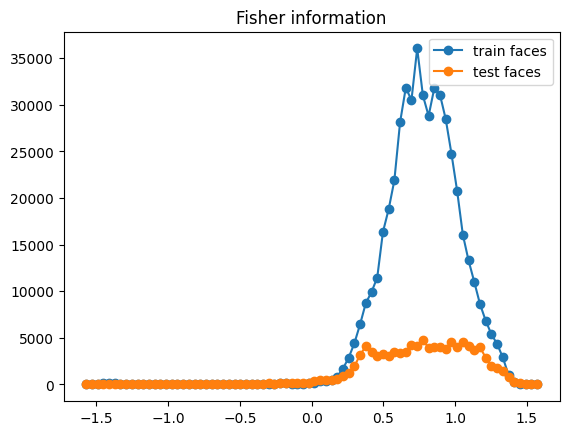

```python
plt.plot(xs, FI_train, '-o', label='train faces')
plt.plot(xs, FI_test, '-o', label='test faces')
plt.legend()
plt.title('Fisher information')
```

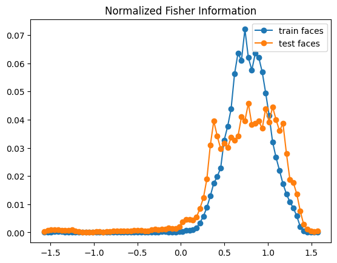

```python
plt.plot(xs, FI_train / FI_train.sum(), '-o', label='train faces')
plt.plot(xs, FI_test / FI_test.sum(), '-o', label='test faces')
plt.legend()
plt.title('Normalized Fisher Information')
```

Notes:

### Aside: Comparison to Fisher information measurements from file

```python
xs = torch.linspace(-torch.pi/2, torch.pi/2, 20)
FI_notebook = Fisher_derivatives_faces_mean(optimal_model, xs, split='test')
```

```python
%run discriminationAnalysis.py
```

```python
FI_file = Fisher_derivatives_faces_mean(optimal_model, xs)
```

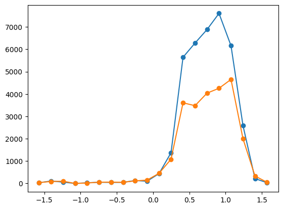

```python
plt.plot(xs, FI_file, '-o')
plt.plot(xs, FI_notebook, '-o')
```

Why are these different? Why is the version in the file so much slower?

Ans: the version in the file is sampling differently from the underlying face dataset.

Code improvements: the FI measurement should take the split from the model itself, not from externally.

### FI Continued

```python
from datageneration.faces.rotated_olivetti import FaceDataset

def make_data(angles, split='test'):
    #print(split)
    numbers = (330, 30, 40)
    all_angles = np.repeat(angles, numbers[0])

    dataset = FaceDataset(all_angles, split=split, numbers=numbers)
    return dataset

def Fisher_derivatives_faces_mean(model, thetas, image_delta=0.05, split='test'):
    """ The mean term in the Fisher information, as evaluated by derivatives of the neural network
    """
    def point_Fisher(theta):
        I0 = make_data(torch.zeros(1) + theta, split=split).images.contiguous()
        I0.requires_grad = True

        outputs = model.forward(I0.to(model.device)).cpu()
        model_grad0 = torch.autograd.grad(outputs.mean(0)[0], I0, retain_graph=True)[0]
        model_grad1 = torch.autograd.grad(outputs.mean(0)[1], I0)[0]

        plus_I0 = make_data(torch.zeros(1) + theta + image_delta/2, split=split).images.contiguous()
        minus_I0 = make_data(torch.zeros(1) + theta - image_delta/2, split=split).images.contiguous()
        image_deriv = (plus_I0 - minus_I0) / image_delta

        full_deriv0 = (model_grad0 * image_deriv).sum().item()
        full_deriv1 = (model_grad1 * image_deriv).sum().item()
        douts = torch.tensor([full_deriv0, full_deriv1])

        cov = outputs.T.cov().detach()
        torch.mps.empty_cache()
        return (douts @ torch.linalg.inv(cov) @ douts).item()

    FIs = np.zeros(len(thetas))
    for i, theta in enumerate(thetas):
        #print(theta)
        FIs[i] = point_Fisher(theta)

    return FIs
```

```python
xs = torch.linspace(-torch.pi/2, torch.pi/2, 80)
FI_train = Fisher_derivatives_faces_mean(optimal_model, xs, split='train')
FI_test = Fisher_derivatives_faces_mean(optimal_model, xs, split='test')
```

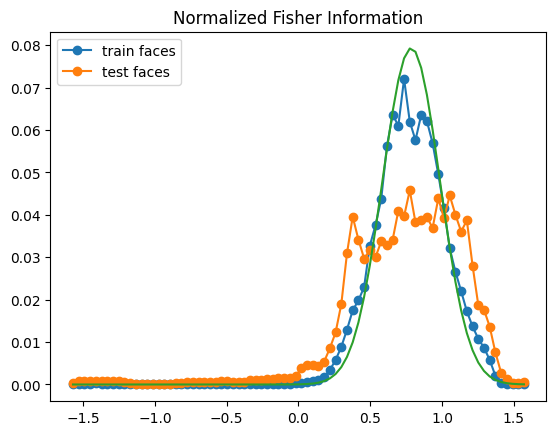

```python
plt.plot(xs, FI_train / FI_train.sum(), '-o', label='train faces')
plt.plot(xs, FI_test / FI_test.sum(), '-o', label='test faces')
plt.plot(xs, norm(torch.pi/4, 0.2).pdf(xs) / norm(torch.pi/4, 0.2).pdf(xs).sum())
plt.legend()
plt.title('Normalized Fisher Information')
```

Aha. The generalization performance is a worse approximation of the distribution that we put in.

This actually could be quite an interesting thing to study.

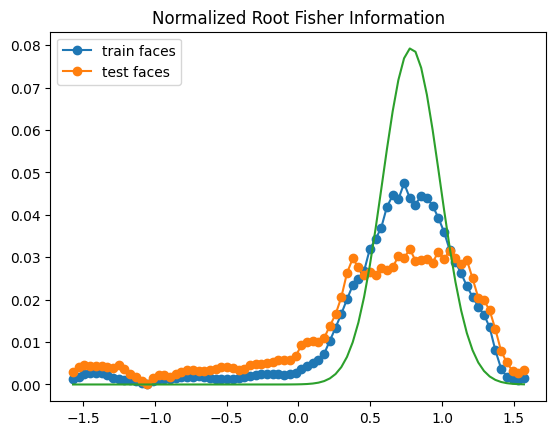

```python
root_FI_train = FI_train**0.5
root_FI_train = root_FI_train / root_FI_train.sum()

root_FI_test = FI_test**0.5
root_FI_test = root_FI_test / root_FI_test.sum()

plt.plot(xs, root_FI_train, '-o', label='train faces')
plt.plot(xs, root_FI_test, '-o', label='test faces')
plt.plot(xs, norm(torch.pi/4, 0.2).pdf(xs) / norm(torch.pi/4, 0.2).pdf(xs).sum())
plt.legend()
plt.title('Normalized Root Fisher Information')
```

### Thinking about iterations

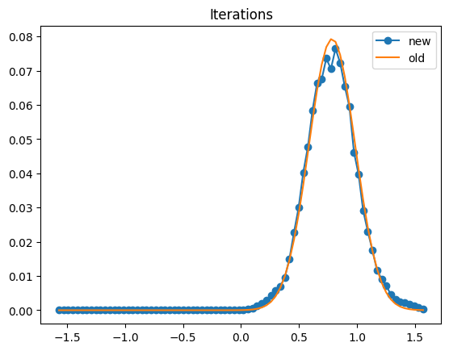

```python
root_FI_test = FI_test**0.5
new_dist = norm(torch.pi/4, 0.2).pdf(xs) / root_FI_test
new_dist = new_dist / new_dist.sum()

old_dist = norm(torch.pi/4, 0.2).pdf(xs)
old_dist = old_dist / old_dist.sum()

plt.plot(xs, new_dist, '-o', label='new')
plt.plot(xs, old_dist, label='old')
plt.legend()
plt.title('Iterations')
```

Oh snap. That actually looks pretty good.....

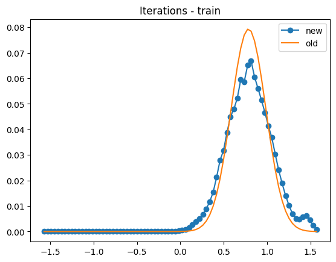

```python
root_FI_train = FI_train**0.5
new_dist = norm(torch.pi/4, 0.2).pdf(xs) / root_FI_train
new_dist = new_dist / new_dist.sum()

old_dist = norm(torch.pi/4, 0.2).pdf(xs)
old_dist = old_dist / old_dist.sum()

plt.plot(xs, new_dist, '-o', label='new')
plt.plot(xs, old_dist, label='old')
plt.legend()
plt.title('Iterations - train')
```

Lol. By this metric, the train distribution actually looks worse!

And the test set distribution looks really good. How is this possible? How is it possible that the FI is not uniform, but doesn't really change the dsitribution?

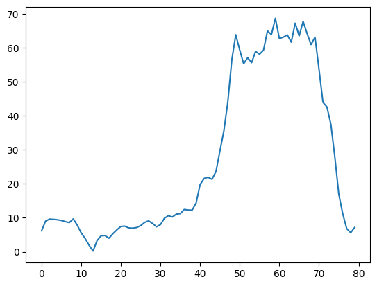

```python
plt.plot(root_FI_test)
```

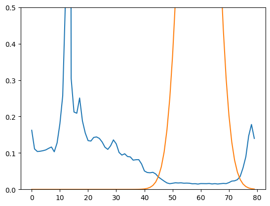

```python
plt.plot(1 / root_FI_test)
plt.ylim(0, 0.5)

plt.plot(norm(torch.pi/4, 0.2).pdf(xs) )
```

I see. The Fisher information in this case is constant *over the support* of the distribution. This is why we get essentially the same distribution out that we put in.

#### What if this distribution of outputs were constant?

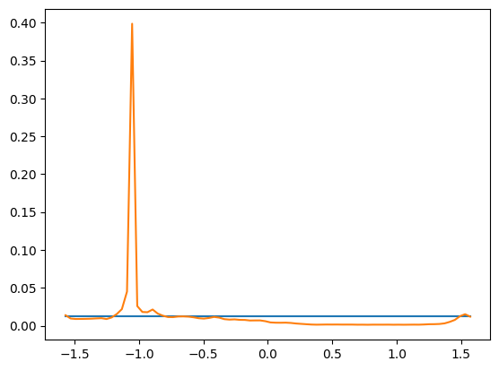

```python
root_FI_test = FI_test**0.5

initial_step = torch.ones(xs.shape) / xs.shape[0]
next_step = initial_step / root_FI_test
next_step = next_step / next_step.sum()

plt.plot(xs, initial_step)
plt.plot(xs, next_step)
```

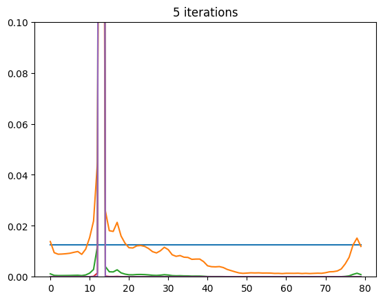

```python
root_FI_test = FI_test**0.5

curr_step = torch.ones(xs.shape) / xs.shape[0]
for step in range(5):
    plt.plot(curr_step)
    next_step = curr_step / root_FI_test
    curr_step = next_step / next_step.sum()
plt.ylim([0, 0.1])
plt.title('5 iterations')
```

Yeah... This is not converging... In fact, it's diverging

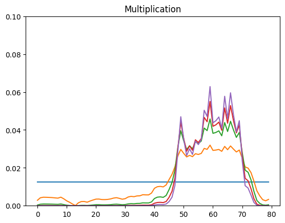

```python
root_FI_test = FI_test**0.5

curr_step = torch.ones(xs.shape) / xs.shape[0]
for step in range(5):
    plt.plot(curr_step)
    next_step = curr_step * root_FI_test
    curr_step = next_step / next_step.sum()
plt.ylim([0, 0.1])

plt.title('Multiplication')
```

This one does seem to convege, toward the the Fisher information distiribution.

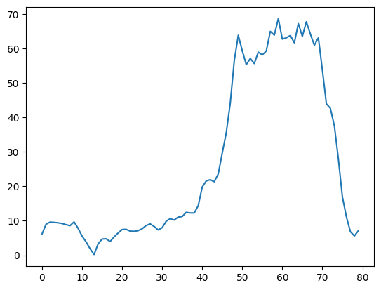

```python
plt.plot(root_FI_test)
```

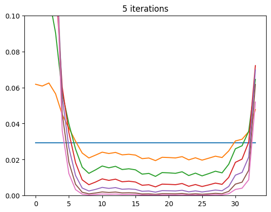

```python
root_FI_test = FI_test**0.5
root_FI_test = root_FI_test[root_FI_test >=20]


curr_step = torch.ones(root_FI_test.shape) / root_FI_test.shape[0]
for step in range(7):
    plt.plot(curr_step)
    next_step = curr_step / root_FI_test
    curr_step = next_step / next_step.sum()
plt.ylim([0, 0.1])
plt.title('5 iterations')
```

Hmmmm. Even removing the extreme values, this one still converges to a zero / one step function.

I think there must be something that I'm missing...probably the distribution in the output space.

Like, it is possible that these dynamics are created, but more likely that concentrating stimuli is going to result in some concentration at their locations.

### Including the output density

#### Uniform inputs

```python
s_values = np.pi * torch.rand(1000) - np.pi/2

images = make_data(s_values, split='test')
```

```python
inputs = images[:]['image']

outputs = optimal_model.forward(inputs.to(optimal_model.device)).detach().cpu()
```

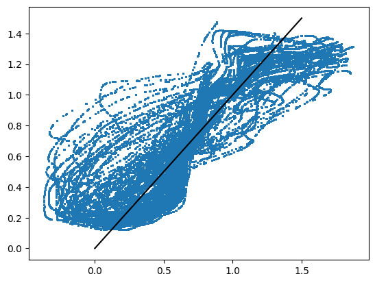

```python
xs = np.linspace(-0., 1.5)
plt.plot(xs, xs, 'k')
plt.scatter(outputs[:,0], outputs[:,1], s=1)
```

This has a pretty interesting structure:

1. It looks line a set of lines, probably one for each image.
2. Is it concentrated?

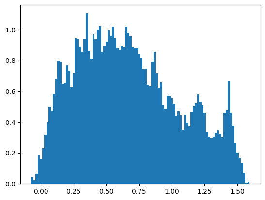

```python
outs = plt.hist(optimal_model.decodeAngles(outputs).squeeze(), bins=100, density=True)
```

```python
xs = torch.linspace(-torch.pi/2, torch.pi/2, 80)
FI_test = Fisher_derivatives_faces_mean(optimal_model, xs, split='test')
root_FI_test = FI_test**0.5 / (FI_test**0.5).sum()
```

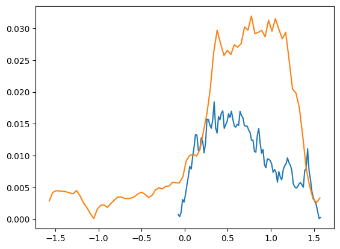

```python
plt.plot(outs[1][0:-1], outs[0] / outs[0].sum())
plt.plot(xs, root_FI_test)
```

Yes! The density is similarly concentrated, so I shouldn't expect the result to behave like the previous.

```python
bins = outs[1][0:-1]
FI_test = Fisher_derivatives_faces_mean(optimal_model, bins, split='test')
root_FI_test = FI_test**0.5 / (FI_test**0.5).sum()
```

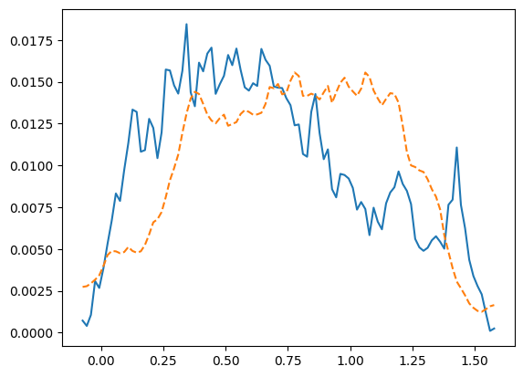

```python
plt.plot(bins, outs[0] / outs[0].sum())
plt.plot(bins, root_FI_test, '--')
```

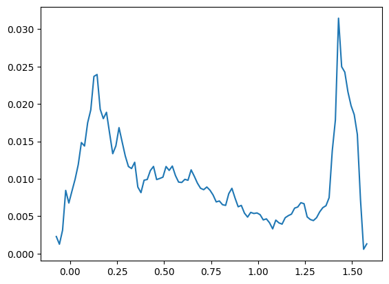

```python
ratio = outs[ 0] / root_FI_test
ratio = ratio / ratio.sum()
plt.plot( bins, ratio)
```

This is a pretty interesting output: the probability density is larger than the FI on the outside corners. In other words, the Fisher information falls off faster near the edges of the effective domain than the probability density. I think that this is because the input distribution, uniform, is more concentrated at the outside than the training distribution.

The question remains: isn't this taking us away from the fixed-point constraint distribution? Like, assuming that the encoding doesn't change, this should simply result in more and more concentration near the edges as iterations pass by.

Might that be because of the constraint vs probability interpretation?

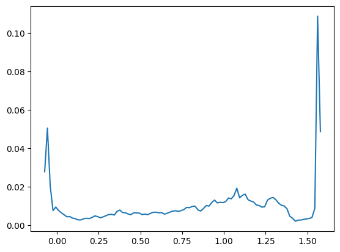

```python
ratio =  root_FI_test / outs[ 0]
ratio = ratio / ratio.sum()
plt.plot( bins, ratio)
```

The inverse iteration doesn't look any better.

#### Baseline density

```python
s_values =  norm(torch.pi/4, 0.2).rvs(1000)
images = make_data(s_values, split='test')

inputs = images[:]['image']
outputs = optimal_model.forward(inputs.to(optimal_model.device)).detach().cpu()
```

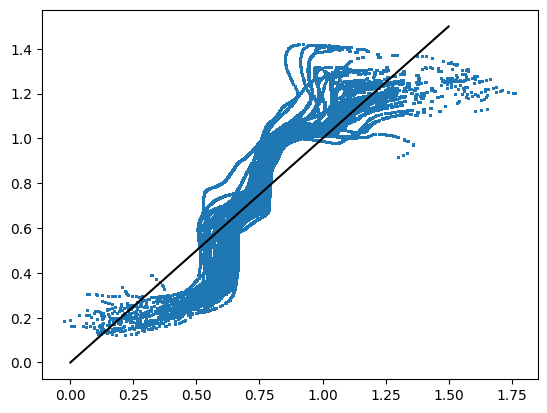

```python
xs = np.linspace(-0., 1.5)
plt.plot(xs, xs, 'k')
plt.scatter(outputs[:,0], outputs[:,1], s=1)
```

Oh. Thats different.

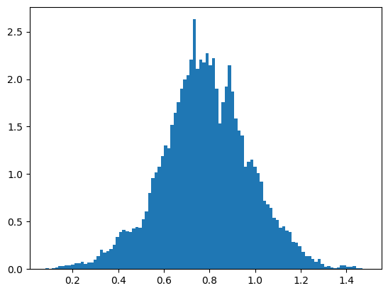

```python
outs = plt.hist(optimal_model.decodeAngles(outputs).squeeze(), bins=100, density=True)
```

```python
bins = outs[1][0:-1]
FI_test = Fisher_derivatives_faces_mean(optimal_model, bins, split='test')
root_FI_test = FI_test**0.5 / (FI_test**0.5).sum()
```

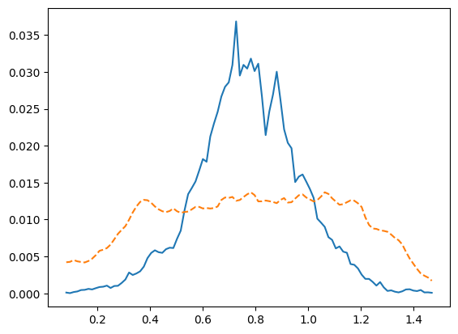

```python
plt.plot(bins, outs[0] / outs[0].sum())
plt.plot(bins, root_FI_test, '--')
```

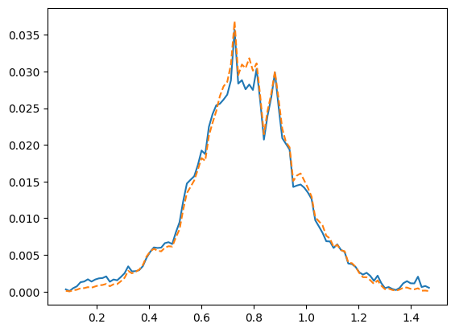

```python
ratio = outs[ 0] / root_FI_test
ratio = ratio / ratio.sum()
plt.plot( bins, ratio)
plt.plot( bins, outs[0] / outs[0].sum(), '--')
```

THis is what I saw before: the distribution that we trained on *does* act as a fixed point. However, this is mostly a result of the fact that the FI is near constant over the support of the training distribution.

### What about the next iteration?

It could be that this diverges, or not depending on how the network handles the updated distributions.

```python
def output_distribution(s_values, model):
    """  """
    images = make_data(s_values, split='test')
    inputs = images[:]['image']

    outputs = model.forward(inputs.to(optimal_model.device)).detach().cpu()
    angles_out = model.decodeAngles(outputs).squeeze()

    return angles_out
```

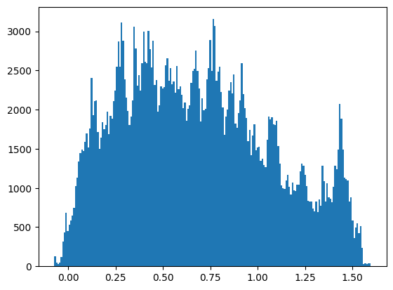

```python
s_values = np.pi * torch.rand(1000) - np.pi/2
s_out = output_distribution(s_values, optimal_model)
_=plt.hist(s_out, bins=200)
```

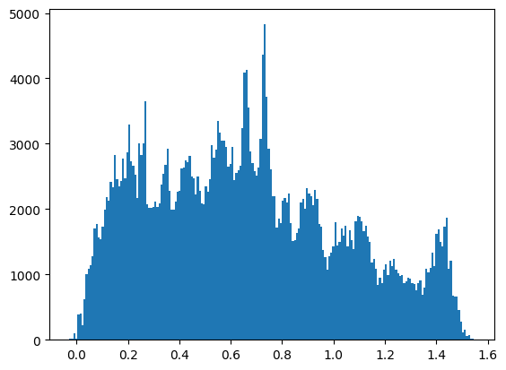

```python
s_values = s_out[ torch.bernoulli(torch.ones(s_out.shape) / 300).bool() ]

s_out = output_distribution(s_values, optimal_model)
_=plt.hist(s_out, bins=200)
```

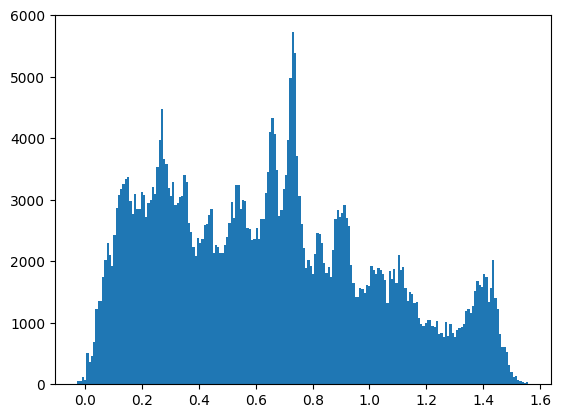

```python
s_values = s_out[ torch.bernoulli(torch.ones(s_out.shape) / 300).bool() ]

s_out = output_distribution(s_values, optimal_model)
_=plt.hist(s_out, bins=200)
```

These particular iterations don't seem terribly unstable....

#### Iteration with selection toward the edges

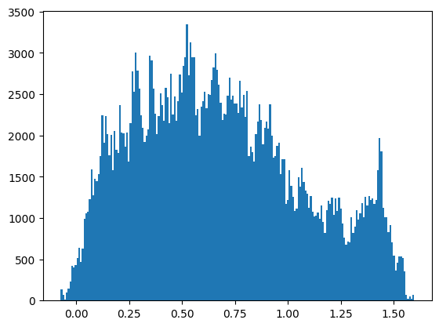

```python
s_values = np.pi * torch.rand(1000) - np.pi/2
s_out = output_distribution(s_values, optimal_model)
_=plt.hist(s_out, bins=200)
```

```python
ps = ((s_out - 0.75)**2)

s_values = s_out[ torch.bernoulli(ps).bool() ]
```

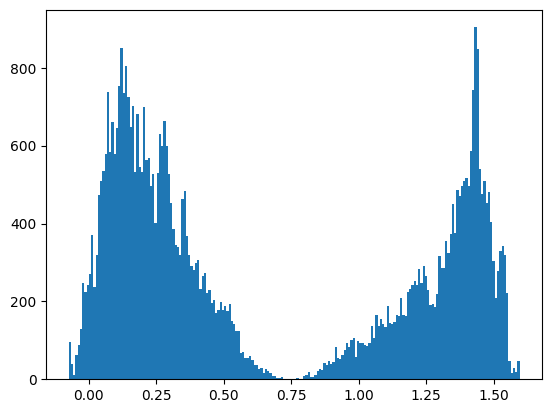

```python
_ = plt.hist(s_values, bins=200)
```

A reasonable approximation for a first look.

```python
s_values = s_values[ torch.bernoulli(torch.ones(s_values.shape) / 50).bool() ]
```

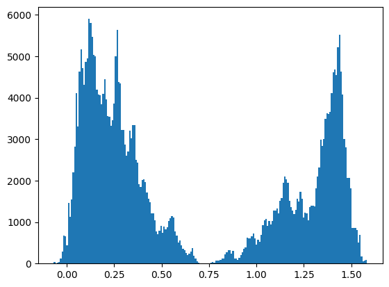

```python
s_out = output_distribution(s_values, optimal_model)
_=plt.hist(s_out, bins=200)
```

```python
ps = ((s_out - 0.75)**2)
s_values = s_out[ torch.bernoulli(ps).bool() ]
s_values = s_values[ torch.bernoulli(torch.ones(s_values.shape) / 50).bool() ]
```

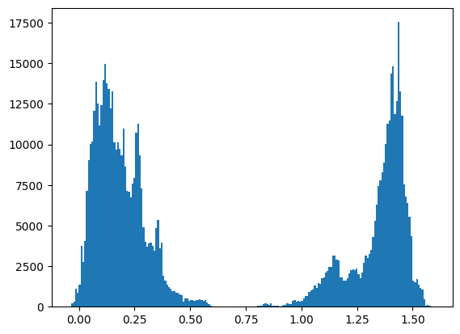

```python
s_out = output_distribution(s_values, optimal_model)
_=plt.hist(s_out, bins=200)
```

```python
ps = ((s_out - 0.75)**2)
s_values = s_out[ torch.bernoulli(ps).bool() ]
s_values = s_values[ torch.bernoulli(torch.ones(s_values.shape) / 250).bool() ]
```

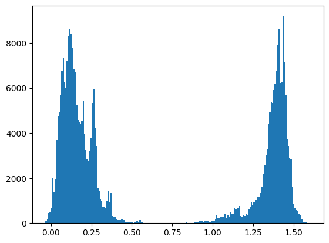

```python
s_out = output_distribution(s_values, optimal_model)
_=plt.hist(s_out, bins=200)
```

Ok, so it does seem to be sparisfying out, slowly loosing room in the middle. Note that part of this could be from stochastic loss of points, but I think that the majority is, in fact, the result of the repeated selection.

It happens slower than I expected, but the selection seems to be pushing toward concentration on the edges.